# 03 - RQ2: SHAP Feature Importance

**Notebook version:** v24 -- 2026-08-02

- Apply TreeExplainer SHAP to the best RQ1 model
- Rank features by mean |SHAP value|
- Cross-check against permutation importance
- Report ALE curves for the top features as a complementary, engineer-facing deliverable

**Why SHAP over TreeInterpreter:** TreeInterpreter's Saabas-style decomposition is provably inconsistent (Lundberg, Erion, & Lee, 2018) -- it can lower a feature's assigned importance even when that feature's true impact increases. TreeExplainer was built to fix exactly this, and also (unlike TreeInterpreter) covers both Random Forest and XGBoost with the same exact algorithm. See `docs/synopsis.docx`, "Solution to RQ2" for the full rationale, including the parallel discussion of why LIME was set aside (`src/feature_selection.py` docstring covers PCA).

```python
# --- Colab setup: run this cell first if you opened this notebook from GitHub in Colab ---
# If you're running locally in Jupyter from the notebooks/ folder, this cell does nothing.
# Safe to re-run: always anchors to /content so repeated runs never create nested clones.
# git pull always runs (cheap, ~seconds) so code is never stale even if Colab's
# 'Restart session' left /content on disk from an earlier session -- only
# pip install (the actual slow part) is skipped via the session marker.
import os
import subprocess
from pathlib import Path

try:
    import google.colab
    IN_COLAB = True
except ImportError:
    IN_COLAB = False

REPO_URL = "https://github.com/WJPsystems/secom-explainable-vm.git"
REPO_NAME = "secom-explainable-vm"
SETUP_MARKER = Path("/content/.secom_setup_done")

if IN_COLAB:
    os.chdir("/content")
    if not os.path.exists(REPO_NAME):
        !git clone "{REPO_URL}"
        SETUP_MARKER.unlink(missing_ok=True)  # fresh clone -- force full setup below

    # Always pull -- cheap, and guarantees code is current even if /content
    # persisted on disk from an earlier session (e.g. Colab 'Restart session'
    # rather than a full 'Disconnect and delete runtime').
    os.chdir(f"/content/{REPO_NAME}")
    !git pull
    os.chdir("/content")

    os.chdir(f"/content/{REPO_NAME}/notebooks")

    already_setup = SETUP_MARKER.exists()
    if not already_setup:
        !pip install -q -r ../requirements.txt
        SETUP_MARKER.touch()
        setup_note = "Ran pip install (git pull always runs regardless)."
    else:
        setup_note = "Skipped pip install -- already done earlier this session. git pull always ran above."

    commit_info = subprocess.run(
        ["git", "log", "-1", "--format=%h %ci"], capture_output=True, text=True
    ).stdout.strip()
    print(f"Colab setup complete. Working directory: {os.getcwd()}")
    print(setup_note)
    print(f"Repo commit: {commit_info}")
    print("Compare this commit hash against GitHub's latest commit to confirm you're current.")
else:
    print("Not running in Colab -- assuming local Jupyter launched from the notebooks/ folder.")
```

```
Already up to date.
```

```
Colab setup complete. Working directory: /content/secom-explainable-vm/notebooks
Skipped pip install -- already done earlier this session. git pull always ran above.
Repo commit: b108370 2026-08-03 23:56:30 -0400
Compare this commit hash against GitHub's latest commit to confirm you're current.
```

```python
import sys

# Resolve src/ absolutely, independent of cell run order or current working
# directory -- works whether or not the Colab setup cell above has run yet.
try:
    import google.colab
    _SRC_PATH = "/content/secom-explainable-vm/src"
except ImportError:
    _SRC_PATH = "../src"
if _SRC_PATH not in sys.path:
    sys.path.append(_SRC_PATH)

import numpy as np
import pandas as pd
import shap

from preprocessing import load_raw, screen_missingness, screen_variance, impute_median
from explainability import compute_ale, ale_report_for_top_features
from feature_selection import extract_positive_class_shap
from artifacts import load_model, load_json

X, y = load_raw()
X = impute_median(screen_variance(screen_missingness(X)))

# Load RQ1's actual best TREE ensemble (not a freshly retrained model) --
# see 02_modeling_rq1.ipynb's "Save results for downstream notebooks" cell.
# Scoped to the best TREE model specifically (not necessarily RQ1's overall
# winner) because TreeExplainer only supports tree-based models -- this
# matches the synopsis's stated methodology, not an arbitrary substitution.
rq1_summary = load_json("rq1_summary")
best_tree_name = rq1_summary["best_tree_model_name"]
best_overall_name = rq1_summary["best_overall_model_name"]
model = load_model("rq1_best_tree")

print(f"Loaded RQ1's best tree ensemble: {best_tree_name}")
if best_overall_name != best_tree_name:
    print(
        f"Note: RQ1's overall best model was {best_overall_name}, not a tree "
        f"ensemble -- this SHAP analysis explains {best_tree_name} specifically, "
        f"per the synopsis's TreeExplainer-based methodology."
    )
```

```
Dropped 32 columns exceeding 40% missingness.
Dropped 126 near-zero-variance columns (threshold=1e-06).
Loaded RQ1's best tree ensemble: RandomForest
```

## Step 1: SHAP global feature ranking

```python
explainer = shap.TreeExplainer(model)
shap_values = explainer.shap_values(X)
sv = extract_positive_class_shap(shap_values)

mean_abs_shap = pd.Series(np.abs(sv).mean(axis=0), index=X.columns).sort_values(ascending=False)
top_features = mean_abs_shap.index[:10].tolist()
print("Top 10 features by mean |SHAP value|:")
print(mean_abs_shap.head(10))
```

```
Top 10 features by mean |SHAP value|:
Sensor_60     0.011760
Sensor_104    0.008833
Sensor_34     0.006755
Sensor_349    0.005342
Sensor_478    0.004919
Sensor_131    0.004781
Sensor_22     0.004448
Sensor_461    0.004386
Sensor_206    0.004178
Sensor_511    0.003878
dtype: float64
```

## Step 2: Permutation importance cross-check

```python
from sklearn.inspection import permutation_importance

# Permutation importance MUST be evaluated on genuinely held-out data --
# rq1_best_tree (used for SHAP above) was refit on 100% of the data, so
# evaluating permutation importance with it on X/y would silently reuse
# training data. rq1_best_tree_holdout was trained ONLY on train_idx
# specifically so this evaluation is genuine. Using the training-data model
# here previously produced permutation importances of ~1e-17 for every
# feature (floating-point noise) -- a real, not cosmetic, methodological bug.
holdout_model = load_model("rq1_best_tree_holdout")
holdout_split = load_json("rq1_holdout_split")
X_test_ho = X.iloc[holdout_split["test_idx"]]
y_test_ho = y.iloc[holdout_split["test_idx"]]

perm = permutation_importance(
    holdout_model, X_test_ho, y_test_ho, n_repeats=10, random_state=42, scoring='roc_auc', n_jobs=-1
)
perm_importance = pd.Series(perm.importances_mean, index=X.columns).sort_values(ascending=False)
print(f"Top 10 features by permutation importance (evaluated on {len(X_test_ho)} held-out wafers):")
print(perm_importance.head(10))

overlap = set(top_features) & set(perm_importance.index[:10])
print(f"\nOverlap with SHAP top-10: {len(overlap)}/10")
```

```
Top 10 features by permutation importance (evaluated on 314 held-out wafers):
Sensor_60     0.011003
Sensor_29     0.007606
Sensor_206    0.006493
Sensor_17     0.006241
Sensor_228    0.005965
Sensor_281    0.005794
Sensor_132    0.005631
Sensor_430    0.005282
Sensor_492    0.005274
Sensor_268    0.005128
dtype: float64

Overlap with SHAP top-10: 2/10
```

## Step 3: ALE curves for the top features (complementary deliverable)

SHAP tells you *which* sensors matter; ALE tells you *which direction is bad* -- e.g. "fail probability rises sharply once this sensor exceeds X". Used instead of Partial Dependence Plots because ALE stays unbiased under correlated features (Apley & Zhu, 2020), unlike PDP, which assumes feature independence.

```python
ale_curves = ale_report_for_top_features(model, X, top_features, n_bins=20)

for feat, curve in list(ale_curves.items())[:3]:
    print(f"\nALE curve for {feat}:")
    print(curve)
```

```
ALE curve for Sensor_60:
     bin_edge  accumulated_local_effect
0   -28.98820                 -0.006029
1    -6.03880                 -0.004974
2    -4.41890                 -0.004889
3    -3.19307                 -0.004846
4    -2.48836                 -0.004677
5    -1.85545                 -0.004677
6    -1.15874                 -0.004506
7    -0.62936                 -0.004338
8    -0.09198                 -0.004209
9     0.43207                 -0.004167
10    0.94725                 -0.003191
11    1.43604                 -0.001902
12    1.99036                 -0.000535
```

[output cut: 56 more lines]

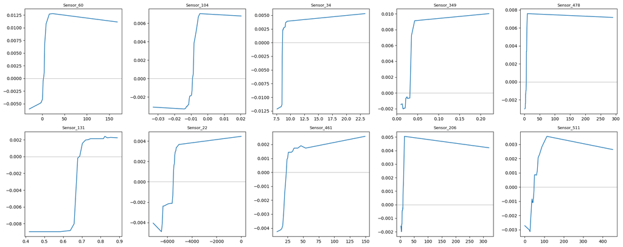

```python
import matplotlib.pyplot as plt

fig, axes = plt.subplots(2, 5, figsize=(20, 8))
for ax, (feat, curve) in zip(axes.flat, ale_curves.items()):
    ax.plot(curve['bin_edge'], curve['accumulated_local_effect'])
    ax.set_title(feat, fontsize=9)
    ax.axhline(0, color='gray', linewidth=0.5)
plt.tight_layout()
plt.savefig('../docs/ale_top10_features.png', dpi=150)
plt.show()
```

## Next steps

- Feed `top_features` (or the nested-CV stabilized version from RQ3) into `04_feature_reduction_rq3.ipynb`
- Report the SHAP ranking, permutation-importance overlap, and ALE curves together in the capstone write-up as the RQ2 deliverable

## Export

Run the cell below last to export this notebook to a standalone HTML file.

```python
# --- Export this notebook to HTML (run this cell last) ---
# Works whether opened live from GitHub in Colab or run locally in Jupyter.
import json
import subprocess

NOTEBOOK_NAME = "03_shap_analysis_rq2"

try:
    import google.colab
    IN_COLAB = True
except ImportError:
    IN_COLAB = False

export_path = f"{NOTEBOOK_NAME}.ipynb"
live_export_available = False

if IN_COLAB:
    # Colab's own notebook JSON isn't the same file as the clone on disk --
    # this pulls the live, currently-run state (including your outputs)
    # directly from the Colab frontend, so nothing gets missed. This only
    # works when there's an actual live frontend attached (i.e. you're running
    # this cell interactively yourself) -- it returns None instead of raising
    # when run unattended (e.g. via 00_run_all.ipynb's automated execution),
    # so that case is caught explicitly here rather than left to crash with a
    # raw TypeError, which used to make 00_run_all's --allow-errors flag mask
    # *real* failures elsewhere in the notebook, not just this expected one.
    from google.colab import _message
    response = _message.blocking_request('get_ipynb', timeout_sec=30)
    if response is not None:
        ipynb_content = response['ipynb']
        with open(export_path, 'w') as f:
            json.dump(ipynb_content, f)
        live_export_available = True
    else:
        print(
            "No live Colab frontend detected (expected when run via "
            "00_run_all.ipynb) -- skipping the live export. 00_run_all does its "
            "own separate HTML export against the already-executed file instead."
        )

if live_export_available or not IN_COLAB:
    html_output = f"{NOTEBOOK_NAME}.html"
    result = subprocess.run(
        ['jupyter', 'nbconvert', '--to', 'html', export_path, '--output', html_output],
        capture_output=True, text=True,
    )
    print(result.stdout)
    if result.returncode != 0:
        print(result.stderr)
    else:
        print(f"Exported to {html_output}")

    if IN_COLAB and result.returncode == 0:
        from google.colab import files
        files.download(html_output)
```

```
No live Colab frontend detected (expected when run via 00_run_all.ipynb) -- skipping the live export. 00_run_all does its own separate HTML export against the already-executed file instead.
```